# DSE 511 Final Project: Data Cleaning

Cecilia Albert-Black

2025-11-04

Set working directory to R code folder

```r
setwd("C:/Users/q4q/repos/DSE511_Final_Project/Step 1. Data Cleaning/R code")
```

Load necessary libraries

```r
library(readr)
library(tidyr)
library(dplyr)
```

```r
library(ggplot2)
library(stringr)
library(lubridate)
```

## Cleaning the NORS Outbreak Dataset

Import raw dataset from Raw data folder

```r
# Import
outbreak_df <- read_csv("C:/Users/q4q/repos/DSE511_Final_Project/Raw data/NORS_outbreaks.csv")
# Preview
head(outbreak_df)
```

```
## # A tibble: 6 × 19
##    Year Month State      `Primary Mode` Etiology    `Serotype or Genotype`
##   <dbl> <dbl> <chr>      <chr>          <chr>       <chr>
## 1  1971     2 California Water          Copper      <NA>
## 2  1971     6 Arkansas   Water          Hepatitis A <NA>
## 3  1971     6 Missouri   Water          Unknown     <NA>
## 4  1971     6 Alabama    Water          Selenium    <NA>
## 5  1971     6 Vermont    Water          Unknown     <NA>
## 6  1971     6 Oregon     Water          Unknown     <NA>
## # ℹ 13 more variables: `Etiology Status` <chr>, Setting <chr>, Illnesses <dbl>,
## #   Hospitalizations <dbl>, `Info On Hospitalizations` <dbl>, Deaths <dbl>,
## #   `Info On Deaths` <dbl>, `Food Vehicle` <chr>,
## #   `Food Contaminated Ingredient` <chr>, `IFSAC Category` <chr>,
## #   `Water Exposure` <chr>, `Water Type` <chr>, `Animal Type` <chr>
```

### 1. Understanding/Inspecting the Dataset

Identify columns and their structure

```r
# Structure
str(outbreak_df)
```

```
## spc_tbl_ [66,713 × 19] (S3: spec_tbl_df/tbl_df/tbl/data.frame)
##  $ Year                        : num [1:66713] 1971 1971 1971 1971 1971 ...
##  $ Month                       : num [1:66713] 2 6 6 6 6 6 7 7 7 7 ...
##  $ State                       : chr [1:66713] "California" "Arkansas" "Missouri" "Alabama" ...
##  $ Primary Mode                : chr [1:66713] "Water" "Water" "Water" "Water" ...
##  $ Etiology                    : chr [1:66713] "Copper" "Hepatitis A" "Unknown" "Selenium" ...
##  $ Serotype or Genotype        : chr [1:66713] NA NA NA NA ...
##  $ Etiology Status             : chr [1:66713] "Confirmed" "Confirmed" "Suspected" "Confirmed" ...
##  $ Setting                     : chr [1:66713] "Restaurant" "Store" "Subdivision/Neighborhood" "Unknown" ...
##  $ Illnesses                   : num [1:66713] 2 98 2 3 3 200 22 187 68 3500 ...
##  $ Hospitalizations            : num [1:66713] NA NA NA NA NA NA NA NA NA NA ...
##  $ Info On Hospitalizations    : num [1:66713] NA NA NA NA NA NA NA NA NA NA ...
##  $ Deaths                      : num [1:66713] 0 0 0 0 0 0 0 0 0 0 ...
##  $ Info On Deaths              : num [1:66713] NA NA NA NA NA NA NA NA NA NA ...
##  $ Food Vehicle                : chr [1:66713] NA NA NA NA ...
##  $ Food Contaminated Ingredient: chr [1:66713] NA NA NA NA ...
##  $ IFSAC Category              : chr [1:66713] NA NA NA NA ...
##  $ Water Exposure              : chr [1:66713] "Drinking water" "Drinking water" "Drinking water" "Drinking water" ...
##  $ Water Type                  : chr [1:66713] "Community" "Other" "Community" "Individual/Private" ...
##  $ Animal Type                 : chr [1:66713] NA NA NA NA ...
##  - attr(*, "spec")=
##   .. cols(
##   ..   Year = col_double(),
##   ..   Month = col_double(),
##   ..   State = col_character(),
##   ..   `Primary Mode` = col_character(),
##   ..   Etiology = col_character(),
##   ..   `Serotype or Genotype` = col_character(),
##   ..   `Etiology Status` = col_character(),
##   ..   Setting = col_character(),
##   ..   Illnesses = col_double(),
##   ..   Hospitalizations = col_double(),
##   ..   `Info On Hospitalizations` = col_double(),
##   ..   Deaths = col_double(),
##   ..   `Info On Deaths` = col_double(),
##   ..   `Food Vehicle` = col_character(),
##   ..   `Food Contaminated Ingredient` = col_character(),
##   ..   `IFSAC Category` = col_character(),
##   ..   `Water Exposure` = col_character(),
##   ..   `Water Type` = col_character(),
##   ..   `Animal Type` = col_character()
##   .. )
##  - attr(*, "problems")=<externalptr>
```

Summary statistics by column using skimr package

```r
library(skimr)
skim(outbreak_df)
```

Data summary

| Name | outbreak_df |
| --- | --- |
| Number of rows | 66713 |
| Number of columns | 19 |
| _______________________ |  |
| Column type frequency: |  |
| character | 12 |
| numeric | 7 |
| ________________________ |  |
| Group variables | None |

**Variable type: character**

| skim_variable | n_missing | complete_rate | min | max | empty | n_unique | whitespace |
| --- | --- | --- | --- | --- | --- | --- | --- |
| State | 0 | 1.00 | 4 | 32 | 0 | 58 | 0 |
| Primary Mode | 0 | 1.00 | 4 | 49 | 0 | 6 | 0 |
| Etiology | 16338 | 0.76 | 3 | 264 | 0 | 787 | 0 |
| Serotype or Genotype | 50243 | 0.25 | 1 | 134 | 0 | 765 | 0 |
| Etiology Status | 16338 | 0.76 | 9 | 129 | 0 | 57 | 0 |
| Setting | 5909 | 0.91 | 4 | 261 | 0 | 597 | 0 |
| Food Vehicle | 54267 | 0.19 | 3 | 314 | 0 | 3779 | 0 |
| Food Contaminated Ingredient | 63963 | 0.04 | 3 | 126 | 0 | 518 | 0 |
| IFSAC Category | 54708 | 0.18 | 3 | 21 | 0 | 26 | 0 |
| Water Exposure | 63607 | 0.05 | 14 | 61 | 0 | 10 | 0 |
| Water Type | 63983 | 0.04 | 4 | 120 | 0 | 56 | 0 |
| Animal Type | 66126 | 0.01 | 3 | 68 | 0 | 61 | 0 |

**Variable type: numeric**

| skim_variable | n_missing | complete_rate | mean | sd | p0 | p25 | p50 | p75 | p100 | hist |
| --- | --- | --- | --- | --- | --- | --- | --- | --- | --- | --- |
| Year | 0 | 1.00 | 2012.70 | 7.55 | 1971 | 2009 | 2014 | 2018 | 2023 | ▁▁▂▃▇ |
| Month | 0 | 1.00 | 5.69 | 3.74 | 1 | 2 | 5 | 9 | 12 | ▇▃▂▂▅ |
| Illnesses | 0 | 1.00 | 33.25 | 1564.41 | 2 | 5 | 14 | 30 | 403000 | ▇▁▁▁▁ |
| Hospitalizations | 8558 | 0.87 | 0.83 | 4.16 | 0 | 0 | 0 | 1 | 308 | ▇▁▁▁▁ |
| Info On Hospitalizations | 8237 | 0.88 | 19.52 | 31.75 | 0 | 3 | 10 | 25 | 872 | ▇▁▁▁▁ |
| Deaths | 7928 | 0.88 | 0.04 | 0.44 | 0 | 0 | 0 | 0 | 50 | ▇▁▁▁▁ |
| Info On Deaths | 8254 | 0.88 | 20.34 | 32.20 | 0 | 4 | 11 | 26 | 872 | ▇▁▁▁▁ |

#### A. Categorical Variables (n = 12)

Determine unique values of categorical variables

##### I. States

The state where the exposure occurred. For a single state of exposure, the state will be listed. For multiple states of exposure, “Multistate” will be listed.

```r
unique(outbreak_df$State)
```

```
##  [1] "California"                       "Arkansas"
##  [3] "Missouri"                         "Alabama"
##  [5] "Vermont"                          "Oregon"
##  [7] "New Jersey"                       "Mississippi"
##  [9] "Kentucky"                         "Oklahoma"
## [11] "New Mexico"                       "North Carolina"
## [13] "New York"                         "Alaska"
## [15] "Texas"                            "Indiana"
## [17] "Colorado"                         "Ohio"
## [19] "Minnesota"                        "Illinois"
## [21] "Florida"                          "Pennsylvania"
## [23] "Washington"                       "Maryland"
## [25] "Massachusetts"                    "Tennessee"
## [27] "Utah"                             "Hawaii"
## [29] "Iowa"                             "West Virginia"
## [31] "Arizona"                          "Virginia"
## [33] "Connecticut"                      "Idaho"
## [35] "New Hampshire"                    "Wisconsin"
## [37] "Montana"                          "Puerto Rico"
## [39] "Louisiana"                        "Kansas"
## [41] "South Carolina"                   "Maine"
## [43] "Wyoming"                          "North Dakota"
## [45] "Michigan"                         "Georgia"
## [47] "South Dakota"                     "Rhode Island"
## [49] "Nevada"                           "Virgin Islands"
## [51] "Multistate"                       "Delaware"
## [53] "Northern Mariana Islands"         "Nebraska"
## [55] "Guam"                             "District of Columbia"
## [57] "Republic of the Marshall Islands" "Republic of Palau"
```

##### II. Primary Mode

Primary mode of transmission.

```r
# Table of unique primary modes
table(outbreak_df$`Primary Mode`)
```

```
##
##                                    Animal contact
##                                               655
## Environmental contamination other than food/water
##                                               132
##                                              Food
##                                             24729
##                             Indeterminate/unknown
##                                              5677
##                                  Person-to-person
##                                             32414
##                                             Water
##                                              3106
```

Change variable name to one word

```r
outbreak_df$Primary_mode <- outbreak_df$'Primary Mode'
```

##### III. Etiology

Genus and species of identified etiology. Multiple reported etiologies are separated by a semicolon.

```r
# Number of unique etiologies
n_distinct(outbreak_df$Etiology)
```

```
## [1] 788
```

```r
# Top 10 Etiologies
outbreak_df %>%
  count(Etiology, sort = TRUE)%>%
  head(20)
```

```
## # A tibble: 20 × 2
##    Etiology                                          n
##    <chr>                                         <int>
##  1 <NA>                                          16338
##  2 Norovirus                                      9668
##  3 Norovirus Genogroup II                         9178
##  4 Norovirus unknown                              8769
##  5 Salmonella enterica                            4124
##  6 Norovirus Genogroup I                          4108
##  7 Escherichia coli, Shiga toxin-producing        1219
##  8 Shigella sonnei                                1172
##  9 Clostridium perfringens                         926
## 10 Legionella pneumophila                          763
## 11 Staphylococcus aureus                           626
## 12 Campylobacter jejuni                            604
## 13 Scombroid toxin                                 497
## 14 Norovirus Genogroup II;Norovirus Genogroup II   487
## 15 Unknown                                         426
## 16 Cryptosporidium unknown                         414
## 17 Bacillus cereus                                 402
## 18 Ciguatoxin                                      381
## 19 Campylobacter unknown                           298
## 20 Bacillus cereus;Clostridium perfringens         259
```

##### IV. Serotype or Genotype

Serotype or genotype of identified etiology. Multiple reported etiologies are separated by a semicolon.

```r
# Number of unique variables
n_distinct(outbreak_df$`Serotype or Genotype`)
```

```
## [1] 766
```

Might be a difficult variable to handle since many are a list of descriptors; will be hard to categorize.

##### V. Etiology Status

Indicates whether or not the identified etiology is laboratory ‘Confirmed’ or ‘Suspected’. Multiple reported etiologies are separated by a semicolon.

```r
# Number of unique variables
n_unique(outbreak_df$`Etiology Status`)
```

```
## [1] 57
```

```r
# Top 10 unique names
unique(outbreak_df$`Etiology Status`)%>%
  head(10)   # top 10
```

```
##  [1] "Confirmed"
##  [2] "Suspected"
##  [3] NA
##  [4] "Suspected;Confirmed"
##  [5] "Confirmed;Confirmed"
##  [6] "Confirmed;Confirmed;Suspected;Suspected"
##  [7] "Confirmed;Suspected"
##  [8] "Confirmed;Confirmed;Confirmed"
##  [9] "Suspected;Suspected;Confirmed"
## [10] "Confirmed;Confirmed;Confirmed;Confirmed"
```

Very messy variable that is hard to interpret - maybe we’ll omit it or find a source that describes it better.

##### VI. Setting

Setting(s) where exposure occurred. For foodborne outbreaks, the setting used is the location where the food was prepared.

```r
n_unique(outbreak_df$Setting)
```

```
## [1] 597
```

Many different settings, some have similarities, might be worth exploring ways to group them using cluster analysis.

##### VII. Food Vehicle

For foodborne outbreaks only, the implicated food. Multiple implicated foods are separated by a semicolon.

```r
# Top 10 food vehicles by rank
outbreak_df %>%
  count(`Food Vehicle`, sort = TRUE) %>%
  head(10)
```

```
## # A tibble: 10 × 2
##    `Food Vehicle`             n
##    <chr>                  <int>
##  1 <NA>                   54267
##  2 oysters, raw             264
##  3 multiple foods           208
##  4 ground beef, hamburger   134
##  5 salad, unspecified       130
##  6 chicken                  115
##  7 chicken, unspecified     104
##  8 sandwich, submarine       92
##  9 pork, BBQ                 87
## 10 chicken, other            85
```

Investigate where the missing values of food vehicle are coming from

```r
outbreak_df %>%
  mutate(
    FoodVehicle_missing = if_else(
      is.na(`Food Vehicle`) | `Food Vehicle` == "", "Missing", "Present")) %>%
  count(`Primary Mode`, FoodVehicle_missing) %>%
  group_by(`Primary Mode`) %>%
  mutate(percent = 100 * n / sum(n)) %>%
  ungroup()
```

```
## # A tibble: 7 × 4
##   `Primary Mode`                               FoodVehicle_missing     n percent
##   <chr>                                        <chr>               <int>   <dbl>
## 1 Animal contact                               Missing               655   100
## 2 Environmental contamination other than food… Missing               132   100
## 3 Food                                         Missing             12283    49.7
## 4 Food                                         Present             12446    50.3
## 5 Indeterminate/unknown                        Missing              5677   100
## 6 Person-to-person                             Missing             32414   100
## 7 Water                                        Missing              3106   100
```

This table shows that about half of the reported food vehicles are missing within the category food within primary mode.

Create a variable flagging missing food vehicle values

```r
outbreak_df <- outbreak_df %>%
  mutate(
    Food_vehicle_missing = if_else(
      is.na(`Food Vehicle`) | trimws(`Food Vehicle`) == "",
      "Missing",
      "Present"
    )
  )
```

Change variable name to one word

```r
outbreak_df$Food_vehicle <- outbreak_df$'Food Vehicle'
```

##### VIII. Food Contaminated Ingredient

For foodborne outbreaks only, indicates the contaminated ingredient. Multiple contaminated ingredients are separated by a semicolon.

```r
# Number of unique variables
n_unique(outbreak_df$`Food Contaminated Ingredient`)
```

```
## [1] 518
```

This might be a redundant variable, consider omitting and just using food vehicle for sake of simplicity.

##### IX. IFSAC Category

For foodborne outbreaks only, the IFSAC food category of the contaminated ingredient. If contaminated ingredients fall into multiple IFSAC categories, “Multiple” will be listed.

```r
unique(outbreak_df$`IFSAC Category`)
```

```
##  [1] NA                      "Fish"                  "Multiple"
##  [4] "Beef"                  "Chicken"               "Eggs"
##  [7] "Dairy"                 "N/A"                   "Fruits"
## [10] "Turkey"                "Pork"                  "Seeded Vegetables"
## [13] "Other"                 "Oils-sugars"           "Grains-beans"
## [16] "Nuts-seeds"            "Crustaceans"           "Vegetable Row Crops"
## [19] "Mollusks"              "Root/Underground"      "Sprouts"
## [22] "Game"                  "Fungi"                 "Herbs"
## [25] "Other Meat"            "Other Aquatic Animals" "Other Poultry"
```

Confirm that this category only exists within Food Vehicle outbreaks and count how many missing values

```r
outbreak_df %>%
  group_by(`Primary Mode`) %>%
  summarize(
    total = n(),
    missing_IFSAC = sum(is.na(`IFSAC Category`)),
    percent_missing = 100 * missing_IFSAC / total
  ) %>%
  arrange(desc(percent_missing))
```

```
## # A tibble: 6 × 4
##   `Primary Mode`                             total missing_IFSAC percent_missing
##   <chr>                                      <int>         <int>           <dbl>
## 1 Animal contact                               655           655           100
## 2 Environmental contamination other than fo…   132           132           100
## 3 Indeterminate/unknown                       5677          5677           100
## 4 Person-to-person                           32414         32414           100
## 5 Water                                       3106          3106           100
## 6 Food                                       24729         12724            51.5
```

Looks good, about half of food borne outbreaks contain IFSAC Categories. Might not be much more informative than Food Vehicle for the sake of our study.

Change variable name to be one word

```r
outbreak_df$IFSAC_category <- outbreak_df$'IFSAC Category'
```

##### X. Water Exposure

For waterborne outbreaks only, the implicated type of water exposure.

```r
# Top 10 water exposure types by rank
outbreak_df %>%
  count(`Water Exposure`, sort = TRUE) %>%
  head(10)
```

```
## # A tibble: 10 × 2
##    `Water Exposure`                                            n
##    <chr>                                                   <int>
##  1 <NA>                                                    63607
##  2 Drinking water                                           1256
##  3 Recreational water -- treated                            1085
##  4 Recreational water -- untreated                           361
##  5 Undetermined water                                        192
##  6 Other/Environmental water                                 180
##  7 Drinking water;Recreational water -- treated               14
##  8 Drinking water;Other/Environmental water                   11
##  9 Drinking water;Undetermined water                           5
## 10 Other/Environmental water;Recreational water -- treated     1
```

Investigate where the missing values are coming from

```r
# Create a column flagging missing vs present values
outbreak_df$Water_exposure_missing <- ifelse(
  is.na(outbreak_df$`Water Exposure`) | trimws(outbreak_df$`Water Exposure`) == "",
  "Missing",
  "Present"
)

# Count by primary mode and missing/present status
outbreak_df %>%
  mutate(
    Waterexposure_missing = if_else(
      is.na(`Water Exposure`) | `Water Exposure` == "", "Missing", "Present")) %>%
  count(`Primary Mode`, Waterexposure_missing) %>%
  group_by(`Primary Mode`) %>%
  mutate(percent = 100 * n / sum(n)) %>%
  ungroup()
```

```
## # A tibble: 6 × 4
##   `Primary Mode`                             Waterexposure_missing     n percent
##   <chr>                                      <chr>                 <int>   <dbl>
## 1 Animal contact                             Missing                 655     100
## 2 Environmental contamination other than fo… Missing                 132     100
## 3 Food                                       Missing               24729     100
## 4 Indeterminate/unknown                      Missing                5677     100
## 5 Person-to-person                           Missing               32414     100
## 6 Water                                      Present                3106     100
```

All outbreaks within water as primary mode of exposure have a designated type of water exposure (in other words, no missing values of water exposure in water-borne outbreaks).

Change variable name to be one word

```r
outbreak_df$Water_exposure <- outbreak_df$'Water Exposure'
```

##### XI. Water Type

For waterborne outbreaks only, a description of the venue (for treated and untreated recreational water), water system (for drinking water) or device/structure (for other/unknown; e.g., steam cleaner, cooling tower, ornamental fountain, etc.) that was the vehicle for waterborne exposure to microbial pathogens, chemicals, or toxins.

```r
n_unique(outbreak_df$`Water Type`)
```

```
## [1] 56
```

```r
# Top 10 water types by rank
outbreak_df %>%
  count(`Water Type`, sort = TRUE)%>%
  head(10)
```

```
## # A tibble: 10 × 2
##    `Water Type`                                          n
##    <chr>                                             <int>
##  1 <NA>                                              63983
##  2 Community                                           693
##  3 Pool - Other Swimming Pool                          511
##  4 Hot Tub/Spa/Whirlpool                               348
##  5 Other                                               346
##  6 Lake/Reservoir                                      283
##  7 Hot Tub/Spa/Whirlpool;Pool - Other Swimming Pool    113
##  8 Individual/Private                                  112
##  9 Unknown                                              76
## 10 Splash Pad/Interactive Fountain /Water Playground    41
```

Change variable name to be one word

```r
outbreak_df$Water_type <- outbreak_df$'Water Type'
```

##### XII. Animal Type

For animal contact outbreaks only, the type of animal involved. Multiple animal types are separated by a semicolon.

```r
# Top 10 animal types by rank
outbreak_df %>%
  count(`Animal Type`, sort = TRUE) %>%
  head(10)
```

```
## # A tibble: 10 × 2
##    `Animal Type`     n
##    <chr>         <int>
##  1 <NA>          66126
##  2 Poultry         184
##  3 Cattle          147
##  4 Dog or puppy     46
##  5 Turtle           41
##  6 Goat             30
##  7 Lizard           25
##  8 Pig               8
##  9 Hedgehog          7
## 10 Sheep             7
```

Change variable name to be one word

```r
outbreak_df$Animal_type <- outbreak_df$'Animal Type'
```

#### B. Numeric Variables (n = 7)

##### I. Year

Year of earliest date of reported illness onset.

```r
# Check if any years are missing
sum(is.na(outbreak_df$Year))
```

```
## [1] 0
```

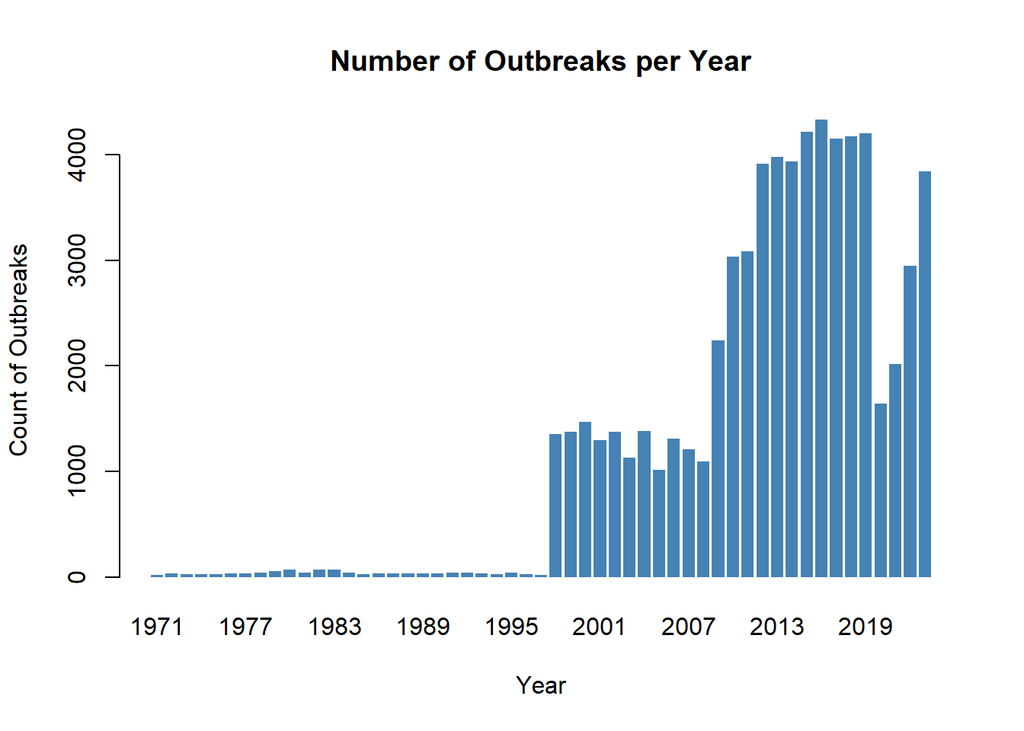

```r
# Count of outbreaks per year


# Visualize number of outbreaks per year
barplot(table(outbreak_df$Year),
        main = "Number of Outbreaks per Year",
        xlab = "Year",
        ylab = "Count of Outbreaks",
        col = "steelblue",
        border = NA)
```

Prior to 1998, outbreaks reported were <1,000 maybe due to lack of proper reporting. Consider using data from 1998-present.

##### II. Month

Month of earliest date of reported illness onset.

```r
# Check if any months are missing within each year

missing_months_by_year <- outbreak_df %>%
  filter(!is.na(Year)) %>%
  group_by(Year) %>%
  summarize(
    observed_months = sort(unique(Month)),
    missing_months = list(setdiff(1:12, unique(Month))),
    n_missing = length(setdiff(1:12, unique(Month)))
  ) %>%
  filter(n_missing > 0)
missing_months_by_year
```

```
## # A tibble: 215 × 4
## # Groups:   Year [21]
##     Year observed_months missing_months n_missing
##    <dbl>           <dbl> <list>             <int>
##  1  1971               2 <int [5]>              5
##  2  1971               6 <int [5]>              5
##  3  1971               7 <int [5]>              5
##  4  1971               8 <int [5]>              5
##  5  1971               9 <int [5]>              5
##  6  1971              11 <int [5]>              5
##  7  1971              12 <int [5]>              5
##  8  1972               3 <int [2]>              2
##  9  1972               4 <int [2]>              2
## 10  1972               5 <int [2]>              2
## # ℹ 205 more rows
```

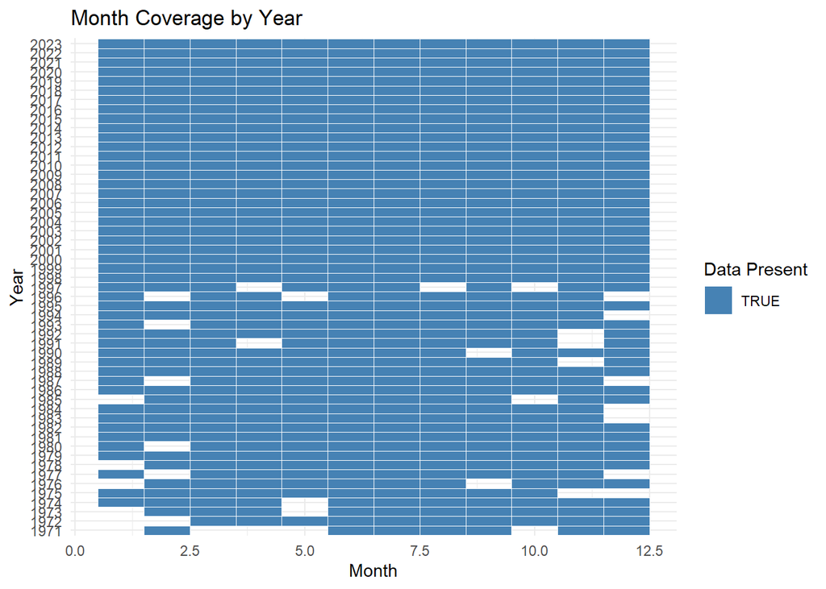

```r
# Visualize this using a heatmap

ggplot(outbreak_df, aes(x = Month, y = factor(Year))) +
  geom_tile(aes(fill = !is.na(Month)), color = "white") +
  scale_fill_manual(values = c("FALSE" = "grey90", "TRUE" = "steelblue")) +
  labs(title = "Month Coverage by Year",
       x = "Month",
       y = "Year",
       fill = "Data Present") +
  theme_minimal()
```

Prior to 1998, some months had no reported outbreaks. This could be true or also indicative of a weak reporting system.

```r
# Frequency of outbreaks by month across all years

month_freq <- outbreak_df %>%
  filter(!is.na(Month)) %>%
  count(Month, sort = TRUE)

month_freq
```

```
## # A tibble: 12 × 2
##    Month     n
##    <dbl> <int>
##  1     1  8883
##  2     2  8491
##  3     3  8398
##  4    12  7235
##  5     4  6220
##  6     5  4806
##  7    11  4490
##  8     6  4075
##  9     7  3866
## 10     8  3623
## 11    10  3422
## 12     9  3204
```

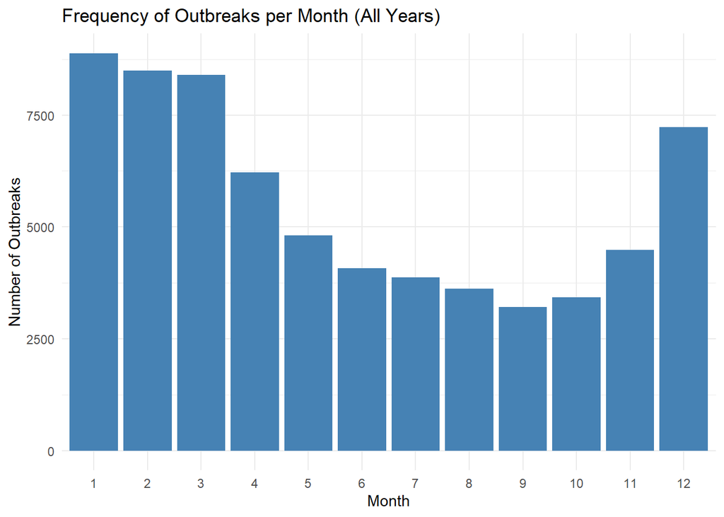

```r
# Visualization of frequency of outbreaks by month across all years
ggplot(outbreak_df, aes(x = factor(Month))) +
  geom_bar(fill = "steelblue") +
  labs(title = "Frequency of Outbreaks per Month (All Years)",
       x = "Month",
       y = "Number of Outbreaks") +
  theme_minimal()
```

This shows the seasonal pattern in outbreak data; month may be a significant predictor of outbreak cases.

##### III. Illness

Estimated total number of primary cases, including lab-confirmed and probable, based on the outbreak-specific definition.

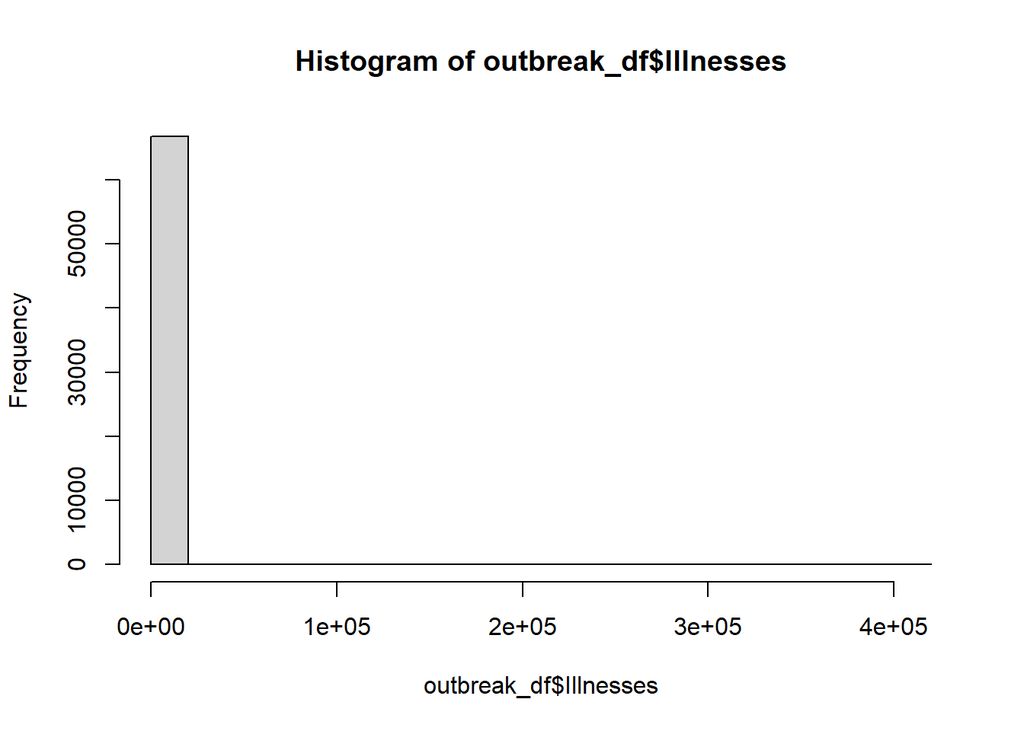

```r
# Histogram of Illnesses by outbreak
hist(outbreak_df$Illnesses)
```

Most outbreaks result in <50 cases of illnesses.

```r
# Check for missing values
sum(is.na(outbreak_df$Illnesses))
```

```
## [1] 0
```

##### IV. Hospitalizations

Number of primary cases who were hospitalized.

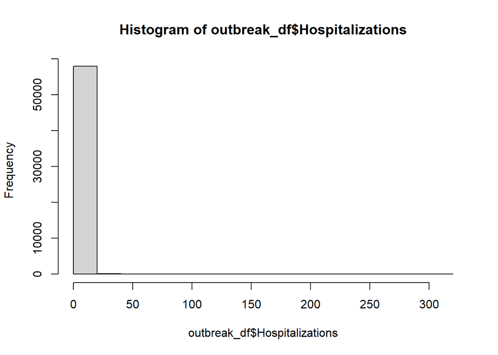

```r
hist(outbreak_df$Hospitalizations)
```

```r
# Check for missing values
sum(is.na(outbreak_df$Hospitalizations))
```

```
## [1] 8558
```

Several missing hospitalizations

##### V. Info on Hospitalizations

Total number of primary cases for whom information on hospitalization is available.

```r
unique(outbreak_df$`Info On Hospitalizations`)
```

```
##   [1]  NA   2 166  45  38  14   3   4  99  25 115   6   5  28  74  18  37  40
##  [19]  36  43  23   8  26  21  11  10  20   0  17   9  31  35  15  22  56  27
##  [37]  71  42  24   7  12  73  83   1  88  80  13  79  48 172 230  51  52  16
##  [55] 209  65  47  53  33  58  41 185 101  50 171  19  46  44 136 112  30 296
##  [73]  72  61  39  84 217 517  32  54  89  34 184 118  67 174 531  29 134  66
##  [91] 347 454  86  63  96  81  55 322  64  60 170 226  91 120 318 501  57 123
## [109] 222  98  70  94  49 100  59  95  92  78 337 108 196 160 125 110 280 151
## [127] 127 111  62 103 346 156 121 157 317 140  82 130 149 270 333 117  75 133
## [145] 116 107  77 204  87 173 218  68 122 106 144 552 228 214 109 104 400 105
## [163] 113 165  69  85 119 201 334 178 146 510  76 250  90 269 276 227 453  97
## [181] 200 224 429 212 132  93 220 210 192 199 872 124 304 102 138 401 495 161
## [199] 247 164 194 236 126 633 205 766 338 145 191 135 516 509 137 162 268 344
## [217] 714 493 198 129 142 114 158 352 131 155 350 245 800 175 167 203 159 148
## [235] 314 139 357 394 150 345 251 225 128 257 154 311 246 213 147 206 152 207
## [253] 143 163 263 312 355 742 197 325 526 256 153 326 141 231 211 242 190 187
## [271] 305 189 265 260 261 365 273 234 282 229 284 180 238 195 179 406 330 528
## [289] 239 183 594 494 369 233 294 408 283 240 216 243 324 182 292 433 620 279
## [307] 181 285 223 188 272 720 252 300 299 275 202 364 708 500 278 169 221 237
## [325] 416 376 438 244 302 557 420 259 377 461 267 363 681 389 647 351 368 293
## [343] 290 186 258 397 524 763 705 208 778 319 362
```

This variable is hard to interpret and provides no additional information from the Hospitalizations variable.

##### VI. Deaths

Number of primary cases who died.

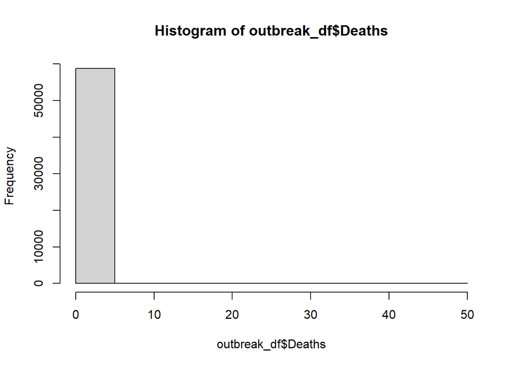

```r
hist(outbreak_df$Deaths)
```

```r
# Check for missing values
sum(is.na(outbreak_df$Deaths))
```

```
## [1] 7928
```

##### VII. Info on Deaths

Total number of primary cases for whom information on hospitalization is available.

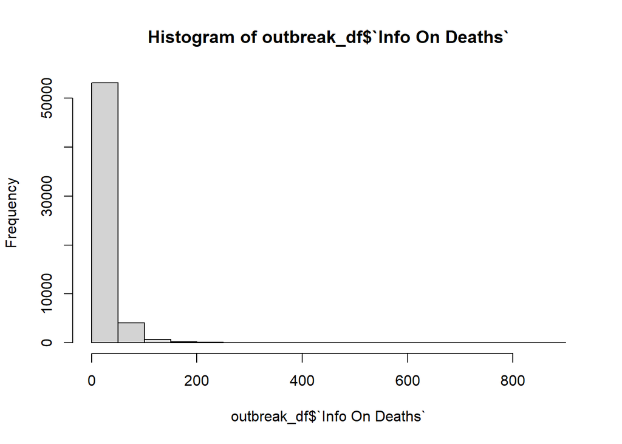

```r
hist(outbreak_df$`Info On Deaths`)
```

### 2. Handling Missing Data

Remove columns with mostly missing values

```r
# Call the columns to drop
columns_to_drop <- c(
  "Serotype or Genotype",
  "Info On Hospitalizations",
  "Info On Deaths",
  "Etiology Status",
  "Food Contaminated Ingredient"
)

# Drop columns
outbreak_df <- outbreak_df %>%
  select(-all_of(columns_to_drop))

# Check
names(outbreak_df)
```

```
##  [1] "Year"                   "Month"                  "State"
##  [4] "Primary Mode"           "Etiology"               "Setting"
##  [7] "Illnesses"              "Hospitalizations"       "Deaths"
## [10] "Food Vehicle"           "IFSAC Category"         "Water Exposure"
## [13] "Water Type"             "Animal Type"            "Primary_mode"
## [16] "Food_vehicle_missing"   "Food_vehicle"           "IFSAC_category"
## [19] "Water_exposure_missing" "Water_exposure"         "Water_type"
## [22] "Animal_type"
```

#### B. Impute NAs

```r
# ---- Define column groups ----
categorical_cols <- c("Etiology", "Setting")

contingent_cols <- c(
  "Food Vehicle",
  "IFSAC Category",
  "Water Exposure",
  "Water Type",
  "Animal Type"
)

numeric_cols <- c("Hospitalizations", "Deaths")

# ---- Fill missing values ----
outbreak_df <- outbreak_df %>%
  mutate(
    # Categorical columns → replace NA with "Unknown"
    across(all_of(categorical_cols), ~ replace_na(., "Unknown")),

    # Contingent categorical columns → replace NA with "Not Applicable"
    across(all_of(contingent_cols), ~ replace_na(., "Not Applicable")),

    # Numeric columns → replace NA with median
    across(all_of(numeric_cols), ~ if_else(is.na(.), median(., na.rm = TRUE), .))
  )

# ---- Check missing values after cleaning ----
missing_summary <- outbreak_df %>%
  summarise(across(everything(), ~ sum(is.na(.)))) %>%
  pivot_longer(everything(), names_to = "column", values_to = "missing_count") %>%
  arrange(desc(missing_count))

print("Missing values after cleaning:")
```

```
## [1] "Missing values after cleaning:"
```

```r
print(missing_summary, n = Inf)
```

```
## # A tibble: 22 × 2
##    column                 missing_count
##    <chr>                          <int>
##  1 Animal_type                    66126
##  2 Water_type                     63983
##  3 Water_exposure                 63607
##  4 IFSAC_category                 54708
##  5 Food_vehicle                   54267
##  6 Year                               0
##  7 Month                              0
##  8 State                              0
##  9 Primary Mode                       0
## 10 Etiology                           0
## 11 Setting                            0
## 12 Illnesses                          0
## 13 Hospitalizations                   0
## 14 Deaths                             0
## 15 Food Vehicle                       0
## 16 IFSAC Category                     0
## 17 Water Exposure                     0
## 18 Water Type                         0
## 19 Animal Type                        0
## 20 Primary_mode                       0
## 21 Food_vehicle_missing               0
## 22 Water_exposure_missing             0
```

### 3. Standardize and Normalize Data

#### A. Standardize categorical variables (e.g., state abbreviations, illness names).

Create a date variable - to combine 2 time variables into 1

```r
# Create a Date variable which combines Month-Year
outbreak_df <- outbreak_df %>%
  mutate(
    Date = sprintf("%04d-%02d", Year, Month)  # formats as "YYYY-MM"
  )
```

Create a state abbreviation variable - for easier interpretation

```r
outbreak_df <- outbreak_df %>%
  mutate(
    State_abbr = state.abb[ match(State, state.name) ]
  )
```

#### B. Normalize numeric variables if you plan to use clustering or distance-based methods.

Standardize count data (create new variables)

```r
outbreak_df <- outbreak_df %>%
  mutate(
    Hospitalizations_std = scale(Hospitalizations),
    Deaths_std = scale(Deaths),
    Illnesses_std = scale(Illnesses)
  )

# Preview
outbreak_df %>%
  select(Hospitalizations_std, Deaths_std, Illnesses_std) %>%
  head(10)
```

```
## # A tibble: 10 × 3
##    Hospitalizations_std[,1] Deaths_std[,1] Illnesses_std[,1]
##                       <dbl>          <dbl>             <dbl>
##  1                   -0.185        -0.0911          -0.0200
##  2                   -0.185        -0.0911           0.0414
##  3                   -0.185        -0.0911          -0.0200
##  4                   -0.185        -0.0911          -0.0193
##  5                   -0.185        -0.0911          -0.0193
##  6                   -0.185        -0.0911           0.107
##  7                   -0.185        -0.0911          -0.00719
##  8                   -0.185        -0.0911           0.0983
##  9                   -0.185        -0.0911           0.0222
## 10                   -0.185        -0.0911           2.22
```

### 4. Feature Engineering

#### I. Animal Group

```r
outbreak_df <- outbreak_df %>%
  mutate(Animal_type_group = case_when(
    is.na(`Animal Type`) ~ "Missing/NA",
    str_detect(`Animal Type`, ";") ~ "Multiple",  # catches multi-animal entries
    str_detect(`Animal Type`, regex("poultry", ignore_case = TRUE)) ~ "Poultry",
    str_detect(`Animal Type`, regex("cattle", ignore_case = TRUE)) ~ "Cattle",
    str_detect(`Animal Type`, regex("cat|dog|ferret|guinea pig|hedgehog|mouse|rat|raccoon", ignore_case = TRUE)) ~ "House Pets",
    str_detect(`Animal Type`, regex("horse|pony|goat|sheep|pig|alpaca|donkey|llama|yak", ignore_case = TRUE)) ~ "Other Ungulates",
    str_detect(`Animal Type`, regex("lizard|turtle|snake|reptile", ignore_case = TRUE)) ~ "Reptiles",
    str_detect(`Animal Type`, regex("bird, not including poultry", ignore_case = TRUE)) ~ "Other Birds",
    str_detect(`Animal Type`, regex("fish", ignore_case = TRUE)) ~ "Fish",
    str_detect(`Animal Type`, regex("frog|salamander", ignore_case = TRUE)) ~ "Amphibians",
    str_detect(`Animal Type`, regex("other", ignore_case = TRUE)) ~ "Other/Unknown",
    TRUE ~ "Other/Unknown"
  ))

# Check the counts for each group
outbreak_df %>%
  count(Animal_type_group, sort = TRUE)
```

```
## # A tibble: 9 × 2
##   Animal_type_group     n
##   <chr>             <int>
## 1 Other/Unknown     66132
## 2 Poultry             188
## 3 Cattle              147
## 4 Reptiles             75
## 5 House Pets           68
## 6 Multiple             49
## 7 Other Ungulates      49
## 8 Fish                  3
## 9 Amphibians            2
```

#### II. Etiology Group

Create a variable that groups etiologies

```r
outbreak_df <- outbreak_df %>%
  mutate(
    Etiology_group = case_when(
      grepl("norovirus", Etiology, ignore.case = TRUE) ~ "Norovirus",
      grepl("salmonella", Etiology, ignore.case = TRUE) ~ "Salmonella",
      grepl("campylobacter", Etiology, ignore.case = TRUE) ~ "Campylobacter",
      grepl("clostridium", Etiology, ignore.case = TRUE) ~ "Clostridium",
      grepl("staphylococcus", Etiology, ignore.case = TRUE) ~ "Staphylococcus",
      grepl("hepatitis", Etiology, ignore.case = TRUE) ~ "Hepatitis",
      grepl("unknown|unspecified|not determined", Etiology, ignore.case = TRUE) ~ "Unknown",
      TRUE ~ "Other"
    )
  )

# Count values by group
outbreak_df %>%
  count(Etiology_group, sort = TRUE)
```

```
## # A tibble: 8 × 2
##   Etiology_group     n
##   <chr>          <int>
## 1 Norovirus      33157
## 2 Unknown        17789
## 3 Other           7597
## 4 Salmonella      4582
## 5 Clostridium     1575
## 6 Campylobacter   1109
## 7 Staphylococcus   757
## 8 Hepatitis        147
```

#### III. Water Type Group

Create a new variable which groups water types

```r
outbreak_df <- outbreak_df %>%
  mutate(
    Water_type_group = case_when(
      is.na(`Water Type`) ~ "Missing/NA",
      grepl("community|individual|private", `Water Type`, ignore.case = TRUE) ~ "Drinking/Community Water",
      grepl("pool|hot tub|spa|whirlpool|splash pad|fountain|water playground", `Water Type`, ignore.case = TRUE) ~ "Recreational Water",
      grepl("lake|reservoir|other", `Water Type`, ignore.case = TRUE) ~ "Natural/Other",
      grepl("unknown|unspecified|not determined", `Water Type`, ignore.case = TRUE) ~ "Unknown",
      TRUE ~ "Other"
    )
  )

# View counts of each group
outbreak_df %>%
  count(Water_type_group, sort = TRUE)
```

```
## # A tibble: 5 × 2
##   Water_type_group             n
##   <chr>                    <int>
## 1 Other                    64075
## 2 Recreational Water        1060
## 3 Drinking/Community Water   856
## 4 Natural/Other              646
## 5 Unknown                     76
```

#### IV. Severity of Outbreak

Since these following variables are nested within each other illnesses(hospitalizations((deaths))), we’ll create 3 new ratios to characterize outbreak severity.

```r
# Compute ratios only when denominator is > 0
outbreak_df <- outbreak_df %>%
  mutate(
    Hosp_per_ill = if_else(Illnesses > 0, Hospitalizations / Illnesses, NA_real_),
    Death_per_hosp = if_else(Hospitalizations > 0, Deaths / Hospitalizations, NA_real_),
    Death_per_ill = if_else(Illnesses > 0, Deaths / Illnesses, NA_real_)
  )

# Mean ratios
outbreak_df %>%
  summarize(
    Mean_hosp_per_ill = mean(Hosp_per_ill, na.rm = TRUE),
    Mean_death_per_hosp = mean(Death_per_hosp, na.rm = TRUE),
    Mean_death_per_ill = mean(Death_per_ill, na.rm = TRUE)
  )
```

```
## # A tibble: 1 × 3
##   Mean_hosp_per_ill Mean_death_per_hosp Mean_death_per_ill
##               <dbl>               <dbl>              <dbl>
## 1            0.0539              0.0423            0.00306
```

Check NAs of new ratio variables

```r
outbreak_df %>%
  summarize(
    na_hosp_per_ill = sum(is.na(Hosp_per_ill)),
    na_death_per_hosp = sum(is.na(Death_per_hosp)),
    na_death_per_ill = sum(is.na(Death_per_ill))
  )
```

```
## # A tibble: 1 × 3
##   na_hosp_per_ill na_death_per_hosp na_death_per_ill
##             <int>             <int>            <int>
## 1               0             51593                0
```

We’ll omit death/hospitalizations since it will be hard to handle NAs

```r
outbreak_df <- outbreak_df %>%
  select(-Death_per_hosp)
```

#### V. Binary Features for Primary Mode

```r
outbreak_df <- outbreak_df %>%
  mutate(
    is_food_related = if_else(str_detect(`Primary Mode`, regex("Food", ignore_case = TRUE)), 1, 0),
    is_water_related = if_else(str_detect(`Primary Mode`, regex("Water", ignore_case = TRUE)), 1, 0),
    is_animal_related = if_else(str_detect(`Primary Mode`, regex("Animal", ignore_case = TRUE)), 1, 0)
  )

# Preview the first few rows
outbreak_df %>%
  select(`Primary Mode`, is_food_related, is_water_related, is_animal_related) %>%
  head(10)
```

```
## # A tibble: 10 × 4
##    `Primary Mode` is_food_related is_water_related is_animal_related
##    <chr>                    <dbl>            <dbl>             <dbl>
##  1 Water                        0                1                 0
##  2 Water                        0                1                 0
##  3 Water                        0                1                 0
##  4 Water                        0                1                 0
##  5 Water                        0                1                 0
##  6 Water                        0                1                 0
##  7 Water                        0                1                 0
##  8 Water                        0                1                 0
##  9 Water                        0                1                 0
## 10 Water                        0                1                 0
```

#### VI. Outbreak Month/Season

```r
outbreak_df <- outbreak_df %>%
  mutate(
    Season = case_when(
      Month %in% c(12, 1, 2) ~ "Winter",
      Month %in% c(3, 4, 5)  ~ "Spring",
      Month %in% c(6, 7, 8)  ~ "Summer",
      Month %in% c(9, 10, 11) ~ "Fall",
      TRUE ~ NA_character_  # in case Month is missing or invalid
    )
  )

# Preview the first few rows
outbreak_df %>%
  select(Month, Season) %>%
  head(10)
```

```
## # A tibble: 10 × 2
##    Month Season
##    <dbl> <chr>
##  1     2 Winter
##  2     6 Summer
##  3     6 Summer
##  4     6 Summer
##  5     6 Summer
##  6     6 Summer
##  7     7 Summer
##  8     7 Summer
##  9     7 Summer
## 10     7 Summer
```

#### VII. Reordering Columns

For readability

```r
# Define the desired column order
desired_order <- c(
  "Year", "Month", "Date", "Season", "State", "State_abbr",
  "Primary_Mode", "Setting", "Etiology", "Etiology_group", "IFSAC_category",
  "Food_vehicle", "Water_exposure", "Water_type", "Water_type_group",
  "Animal_type", "Animal_type_group", "Illnesses", "Hospitalizations", "Deaths",
  "Hospitalizations_std", "Deaths_std", "Illnesses_std",
  "Hosp_per_ill", "Death_per_ill",
  "Food_vehicle_missing", "Water_exposure_missing",
  "is_food_related", "is_water_related", "is_animal_related"
)

# Reorder columns, keeping only those that exist
outbreak_df <- outbreak_df %>%
  select(any_of(desired_order))

# Preview first 10 rows
outbreak_df %>%
  head(10)
```

```
## # A tibble: 10 × 29
##     Year Month Date    Season State   State_abbr Setting Etiology Etiology_group
##    <dbl> <dbl> <chr>   <chr>  <chr>   <chr>      <chr>   <chr>    <chr>
##  1  1971     2 1971-02 Winter Califo… CA         Restau… Copper   Other
##  2  1971     6 1971-06 Summer Arkans… AR         Store   Hepatit… Hepatitis
##  3  1971     6 1971-06 Summer Missou… MO         Subdiv… Unknown  Unknown
##  4  1971     6 1971-06 Summer Alabama AL         Unknown Selenium Other
##  5  1971     6 1971-06 Summer Vermont VT         Commun… Unknown  Unknown
##  6  1971     6 1971-06 Summer Oregon  OR         Restau… Unknown  Unknown
##  7  1971     7 1971-07 Summer New Je… NJ         Camp/c… Hepatit… Hepatitis
##  8  1971     7 1971-07 Summer Missis… MS         Camp/c… Shigell… Other
##  9  1971     7 1971-07 Summer Kentuc… KY         Park -… Unknown  Unknown
## 10  1971     7 1971-07 Summer Califo… CA         Commun… Unknown  Unknown
## # ℹ 20 more variables: IFSAC_category <chr>, Food_vehicle <chr>,
## #   Water_exposure <chr>, Water_type <chr>, Water_type_group <chr>,
## #   Animal_type <chr>, Animal_type_group <chr>, Illnesses <dbl>,
## #   Hospitalizations <dbl>, Deaths <dbl>, Hospitalizations_std <dbl[,1]>,
## #   Deaths_std <dbl[,1]>, Illnesses_std <dbl[,1]>, Hosp_per_ill <dbl>,
## #   Death_per_ill <dbl>, Food_vehicle_missing <chr>,
## #   Water_exposure_missing <chr>, is_food_related <dbl>, …
```

### 5. Save to CSV

```r
# Save to CSV
write.csv(outbreak_df, "outbreak_clean_r_v2.csv", row.names = FALSE)
```